# Part II - Ride Duration: Effects of member characteristics.

## by Ewurabena Bainson

## Investigation Overview

For this investigation I wanted to find out what factors affect ride durations.

## Dataset Overview

The Ford GoBike System data set includes information about individual rides made in a bike-sharing system covering the greater San Francisco Bay area. Within this dataset, there is personal information about the users, duration of the ride, the start and end station amongst others. The datatypes for the Start_time, End_time and member_birth_year columns were changed.

# Distribution of Duration

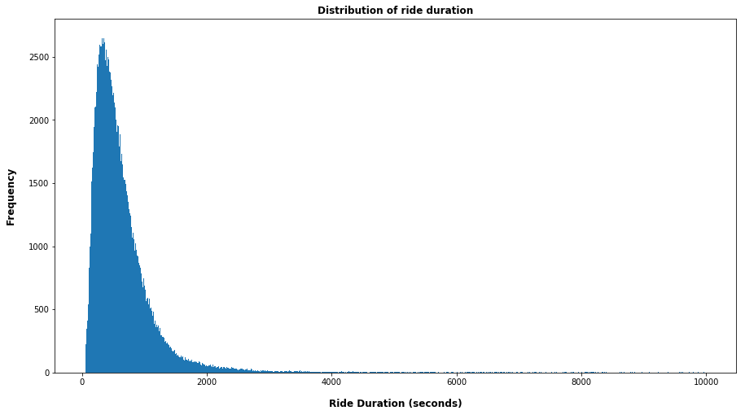

## Gender distribution

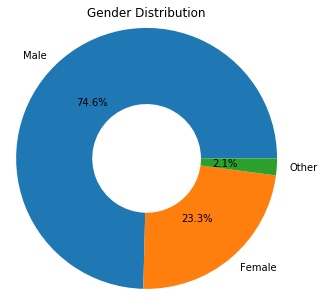

## Member birth years

With members born as early as the 1900s, and as late as the early 2000s; majority of the users are however born between the years 1980 to 2000.

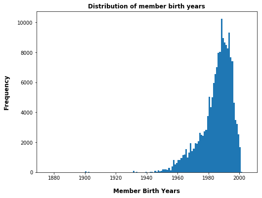

## Ride Duration against gender.

Though seemingly insignificant, males account for the longest ride duration, followed closely by Other gender then females. There is also a greater saturation of female members in the low ride duration region.

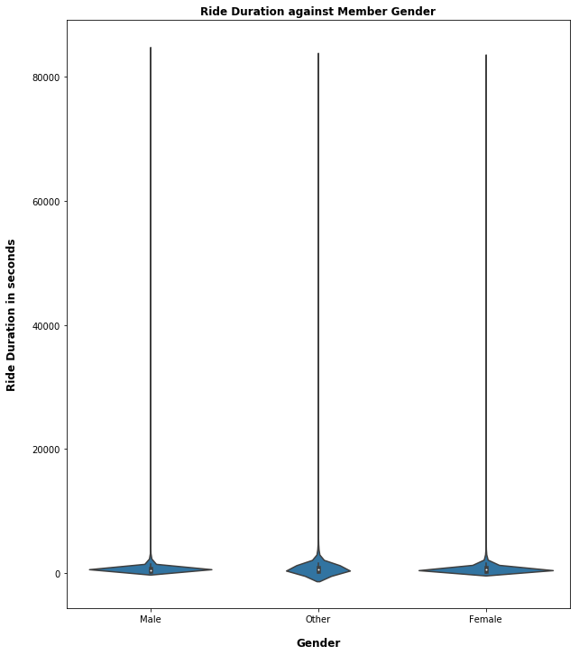